# Chapter 3 Time series decomposition

Leticia

2022-10-06

Analyse trend and cycles

- Calendar adjustments
- Population adjustments
- Inflation adjustments
- Mathematical transformations

# Transformation of GDP to GDP per/capita

## Population adjustments

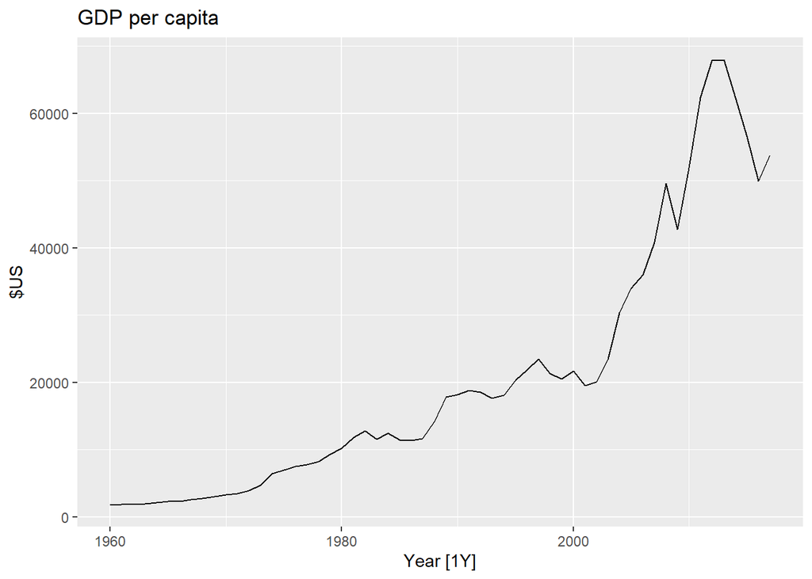

```r
global_economy %>%
  filter(Country == "Australia") %>%
  autoplot(GDP/Population) +
  labs(title= "GDP per capita", y = "$US")
```

## Inflation adjustments

```r
print_retail <- aus_retail %>%
  filter(Industry == "Newspaper and book retailing") %>%
  group_by(Industry) %>%
  index_by(Year = year(Month)) %>%
  summarise(Turnover = sum(Turnover)) #The summation is by year

print_retail
```

```
## # A tsibble: 37 x 3 [1Y]
## # Key:       Industry [1]
##    Industry                      Year Turnover
##    <chr>                        <dbl>    <dbl>
##  1 Newspaper and book retailing  1982    1263
##  2 Newspaper and book retailing  1983    1800.
##  3 Newspaper and book retailing  1984    2011.
##  4 Newspaper and book retailing  1985    2109.
##  5 Newspaper and book retailing  1986    2263.
##  6 Newspaper and book retailing  1987    2534.
##  7 Newspaper and book retailing  1988    2557.
##  8 Newspaper and book retailing  1989    2859.
##  9 Newspaper and book retailing  1990    2891.
## 10 Newspaper and book retailing  1991    2843.
## # ... with 27 more rows
```

```r
aus_economy <- global_economy %>%
  filter(Code == "AUS")
```

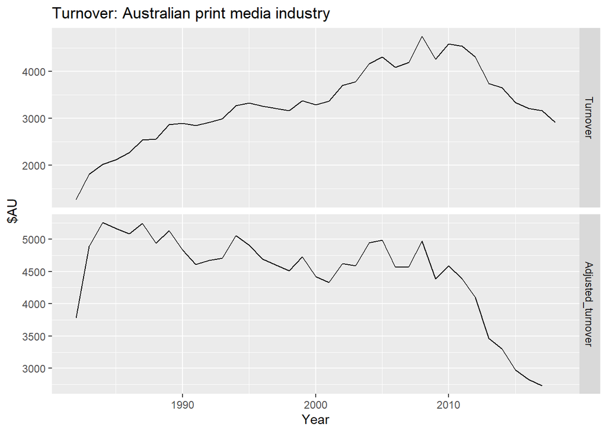

```r
print_retail %>%
  left_join(aus_economy, by = "Year") %>% #joining with the other table by year
  mutate(Adjusted_turnover = Turnover / CPI * 100) %>% #Calculating the turnover (volume de negocios)
  pivot_longer(c(Turnover, Adjusted_turnover),
               values_to = "Turnover") %>% #IDK what this is doing
  mutate(name = factor(name,
         levels=c("Turnover","Adjusted_turnover"))) %>% #has the same value - turnover and adj_turnover, why? Not really, plot will show
  ggplot(aes(x = Year, y = Turnover)) +
  geom_line() +
  facet_grid(name ~ ., scales = "free_y") +
  labs(title = "Turnover: Australian print media industry",
       y = "$AU")
```

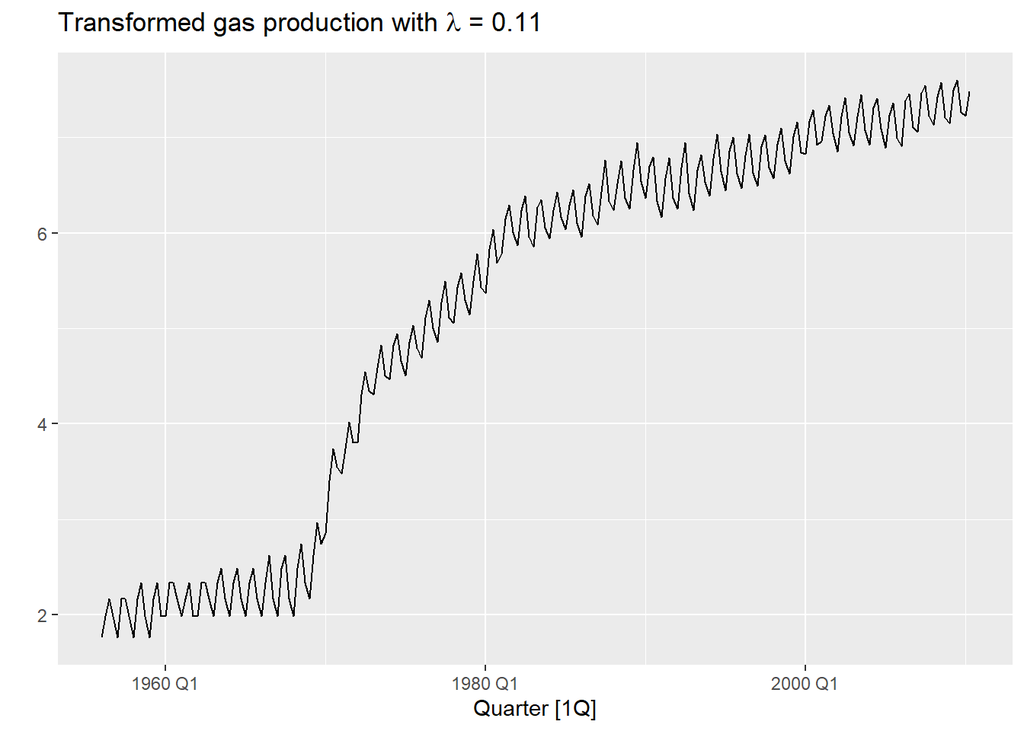

```r
lambda <- aus_production %>%
  features(Gas, features = guerrero) %>%
  pull(lambda_guerrero) #This ill choose lambda
aus_production %>%
  autoplot(box_cox(Gas, lambda)) +
  labs(y = "",
       title = latex2exp::TeX(paste0(
         "Transformed gas production with $\\lambda$ = ",
         round(lambda,2))))
```

# 3.2 Time Series components

Example: Employment in the US retail sector

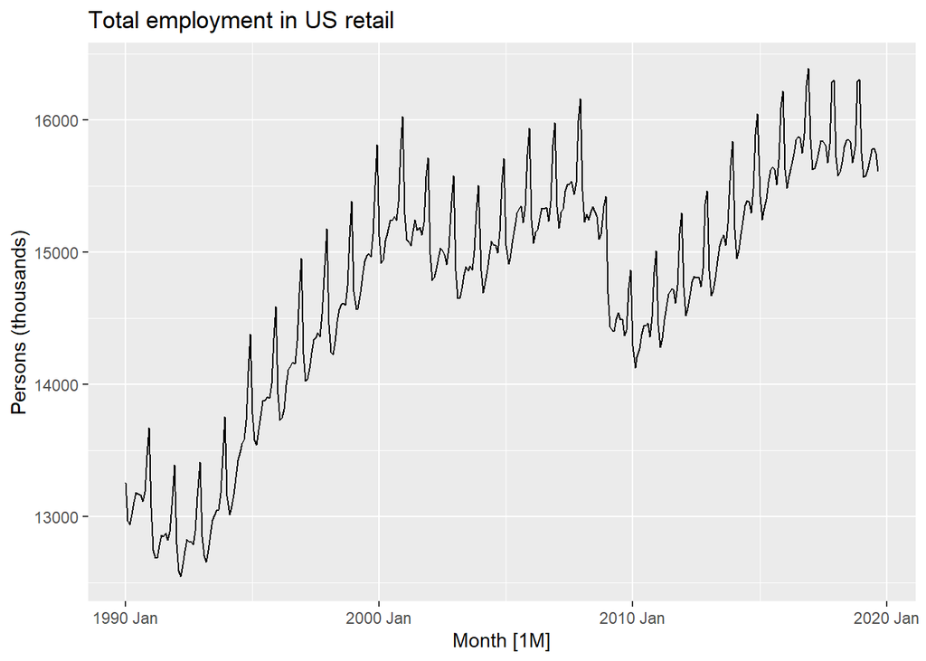

```r
us_retail_employment <- us_employment %>%
  filter(year(Month) >= 1990, Title == "Retail Trade") %>%
  select(-Series_ID)
autoplot(us_retail_employment, Employed) +
  labs(y = "Persons (thousands)",
       title = "Total employment in US retail")
```

```r
dcmp <- us_retail_employment %>%
  model(stl = STL(Employed))
components(dcmp) #Dable - a decomposition table
```

```
## # A dable: 357 x 7 [1M]
## # Key:     .model [1]
## # :        Employed = trend + season_year + remainder
##    .model    Month Employed  trend season_year remainder season_adjust
##    <chr>     <mth>    <dbl>  <dbl>       <dbl>     <dbl>         <dbl>
##  1 stl    1990 Jan   13256. 13288.      -33.0      0.836        13289.
##  2 stl    1990 Feb   12966. 13269.     -258.     -44.6          13224.
##  3 stl    1990 Mar   12938. 13250.     -290.     -22.1          13228.
##  4 stl    1990 Apr   13012. 13231.     -220.       1.05         13232.
##  5 stl    1990 May   13108. 13211.     -114.      11.3          13223.
##  6 stl    1990 Jun   13183. 13192.      -24.3     15.5          13207.
##  7 stl    1990 Jul   13170. 13172.      -23.2     21.6          13193.
##  8 stl    1990 Aug   13160. 13151.       -9.52    17.8          13169.
##  9 stl    1990 Sep   13113. 13131.      -39.5     22.0          13153.
## 10 stl    1990 Oct   13185. 13110.       61.6     13.2          13124.
## # ... with 347 more rows
```

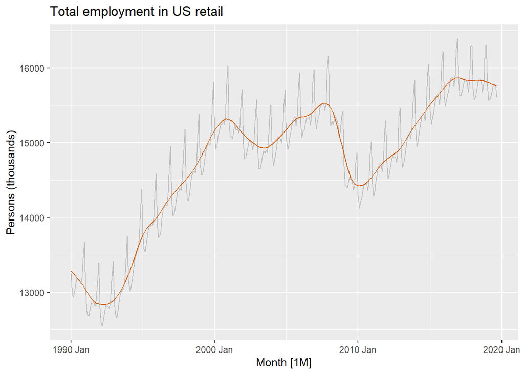

```r
components(dcmp) %>%
  as_tsibble() %>%
  autoplot(Employed, colour="gray") +
  geom_line(aes(y=trend), colour = "#D55E00") + #the y=trend is to add the orange line? Yes. Nice!
  labs(
    y = "Persons (thousands)",
    title = "Total employment in US retail"
  )
```

## Plot all the components by the time frame

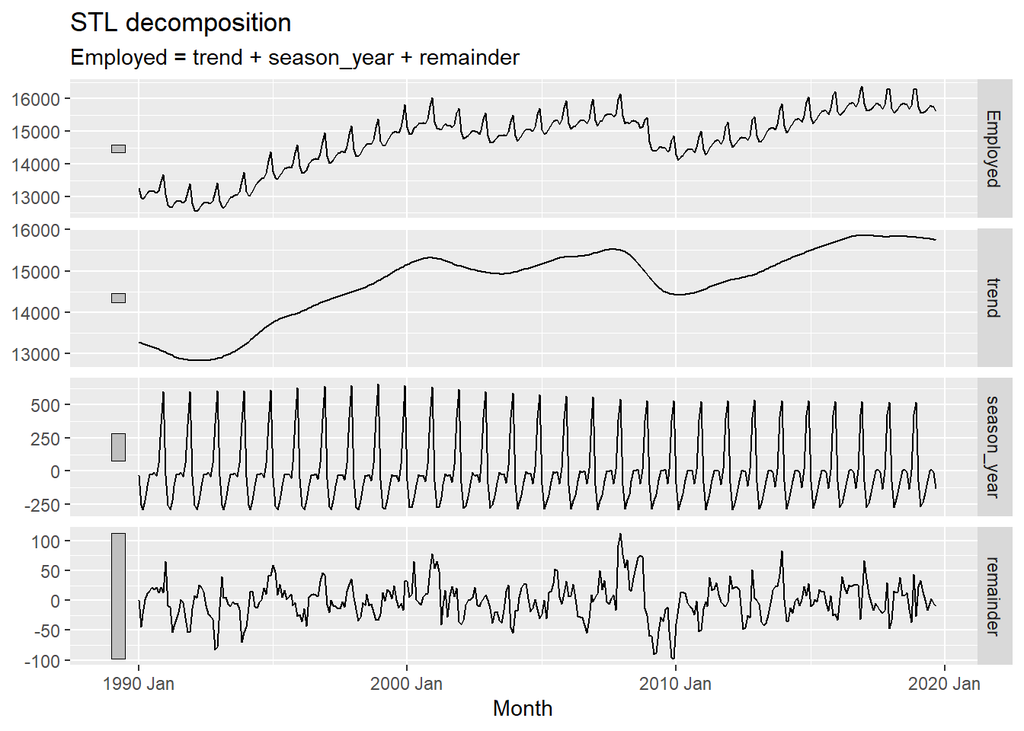

```r
components(dcmp) %>% autoplot() #This code understand to plot all the variables in just one plot, it didn't need the facet
```

## Seasonally adjusted data

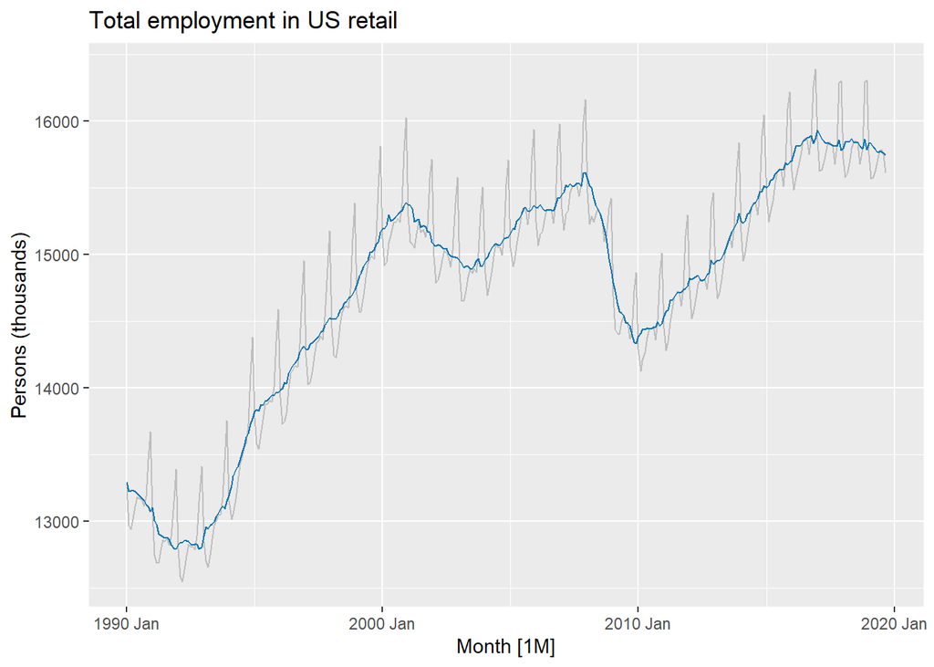

```r
components(dcmp) %>%
  as_tsibble() %>%
  autoplot(Employed, colour = "gray") +
  geom_line(aes(y=season_adjust), colour = "#0072B2") + #another type of adjustment
  labs(y = "Persons (thousands)",
       title = "Total employment in US retail")
```

# 3.3 Moving averages

m-MA, Moving average in order of m. It considers the 2 values after and two values before the average that you want.

This is smooth the curves in the graphs. It takes a period of time and returns the mean for this period (season).

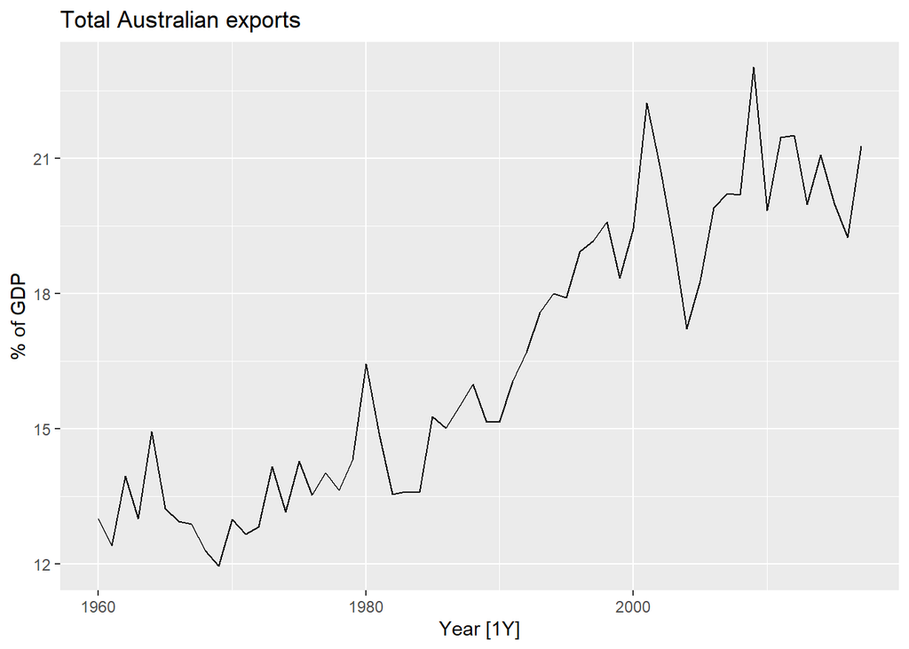

```r
global_economy %>%
  filter(Country == "Australia") %>%
  autoplot(Exports) +
  labs(y = "% of GDP", title = "Total Australian exports")
```

## “Slidding” 5-MA☺

```r
aus_exports <- global_economy %>%
  filter(Country == "Australia") %>%
  mutate(
    `5-MA` = slider::slide_dbl(Exports, mean,
                .before = 2, .after = 2, .complete = TRUE) # It can be 5,7,9 ... assumption: m = 2k+1
  ) #Creating de column with th moving average calculation
```

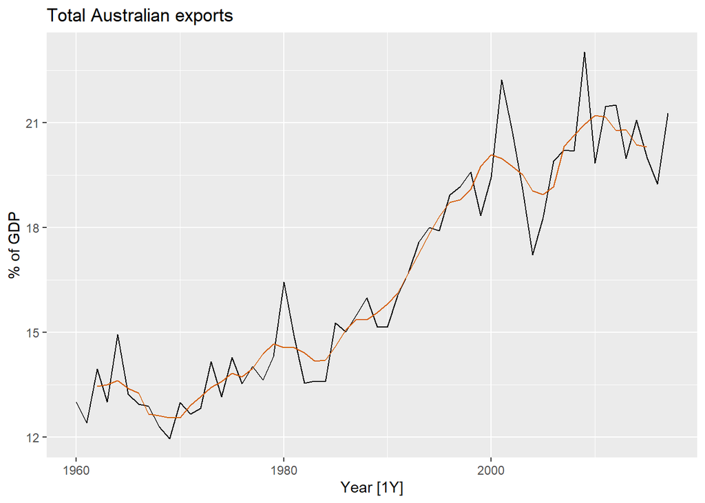

```r
aus_exports %>%
  autoplot(Exports) +
  geom_line(aes(y = `5-MA`), colour = "#D55E00") + #Is this using a column or it's a formula of seasonal behavior?
  labs(y = "% of GDP",
       title = "Total Australian exports") +
  guides(colour = guide_legend(title = "series")) #It excludes the missing values - first to and last two
```

## Moving averages of moving averages

```r
beer <- aus_production %>%
  filter(year(Quarter) >= 1992) %>%
  select(Quarter, Beer)
beer_ma <- beer %>%
  mutate(
    `4-MA` = slider::slide_dbl(Beer, mean,
                .before = 1, .after = 2, .complete = TRUE),
    `2x4-MA` = slider::slide_dbl(`4-MA`, mean,
                .before = 1, .after = 0, .complete = TRUE)
  )
```

## Estimating the trend-cycle with seasonal data

Example: Employment in the US retail sector

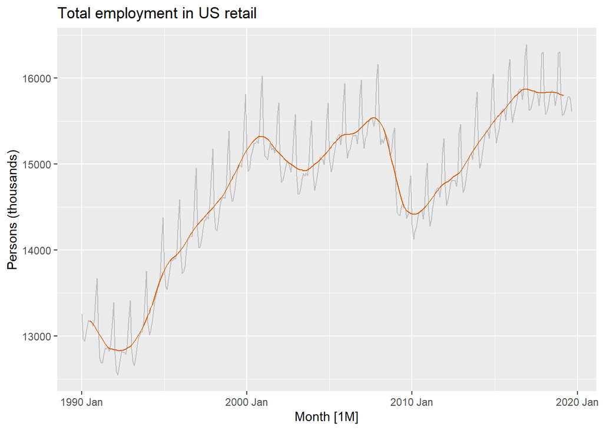

```r
us_retail_employment_ma <- us_retail_employment %>%
  mutate(
    `12-MA` = slider::slide_dbl(Employed, mean,
                .before = 5, .after = 6, .complete = TRUE),
    `2x12-MA` = slider::slide_dbl(`12-MA`, mean,
                .before = 1, .after = 0, .complete = TRUE)
  )
us_retail_employment_ma %>%
  autoplot(Employed, colour = "gray") +
  geom_line(aes(y = `2x12-MA`), colour = "#D55E00") +
  labs(y = "Persons (thousands)",
       title = "Total employment in US retail")
```

# 3.4 Classical decomposition

Assumption: The seasonal component is constant from year to year. # No Covid data included.

## Additive decomposition

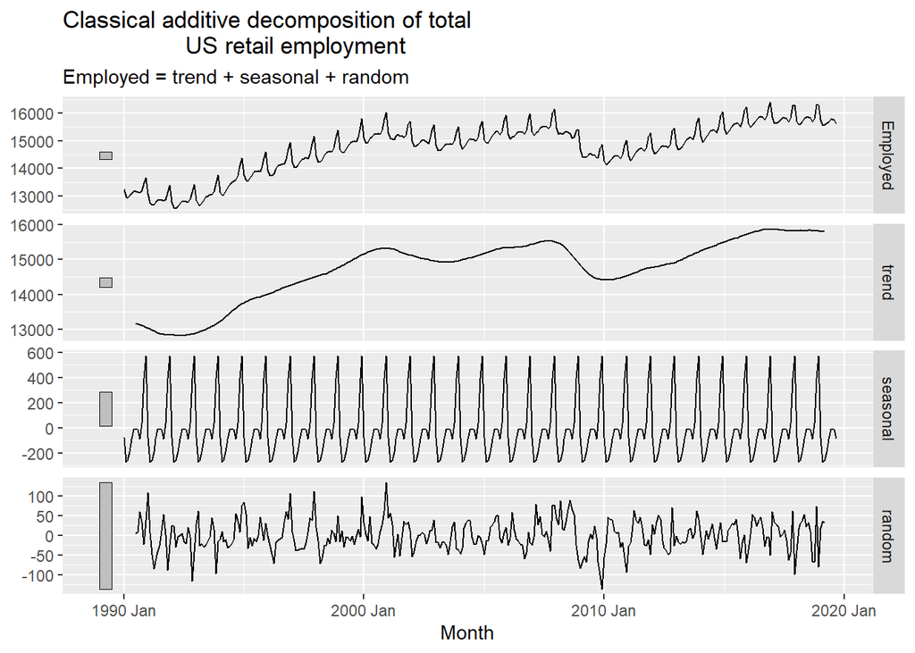

```r
us_retail_employment %>%
  model(
    classical_decomposition(Employed, type = "additive")
  ) %>%
  components() %>%
  autoplot() +
  labs(title = "Classical additive decomposition of total
                  US retail employment")
```

## Multiplicative decomposition Change the subtraction for divisions.

# 3.5 Methods used by official statistics agencies

STL - classical decomposition (additive) X_13ARIMA_SEATS multiplicative decomposition

##X_11

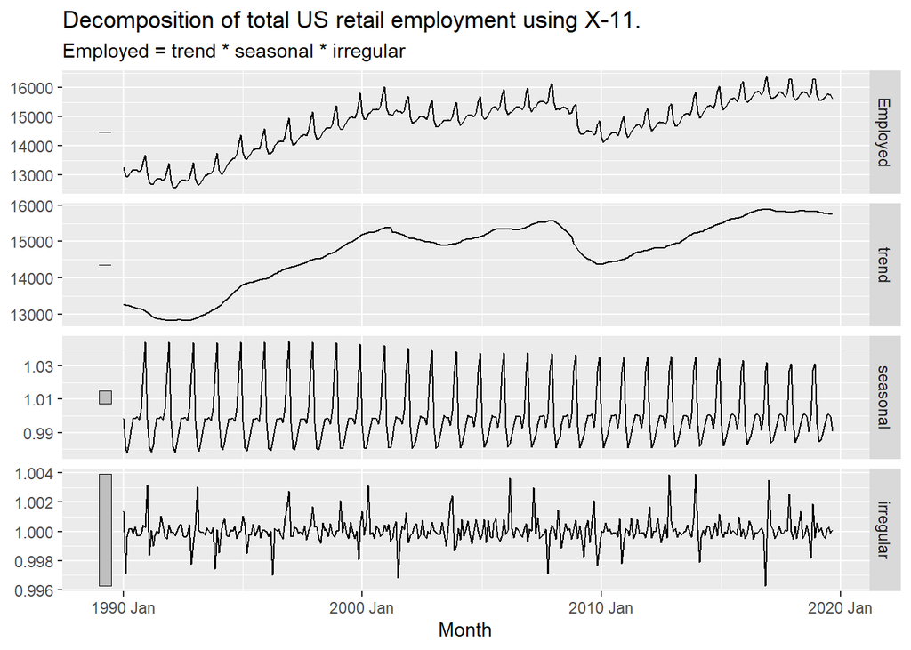

```r
x11_dcmp <- us_retail_employment %>%
  model(x11 = X_13ARIMA_SEATS(Employed ~ x11())) %>% #X_!#ARIMA_SEATS is the decomposition method - x11()?
  components()
autoplot(x11_dcmp) +
  labs(title =
    "Decomposition of total US retail employment using X-11.")
```

US retail employment: the original data (grey), the trend-cycle component (orange) and the seasonally adjusted data (barely visible in blue).

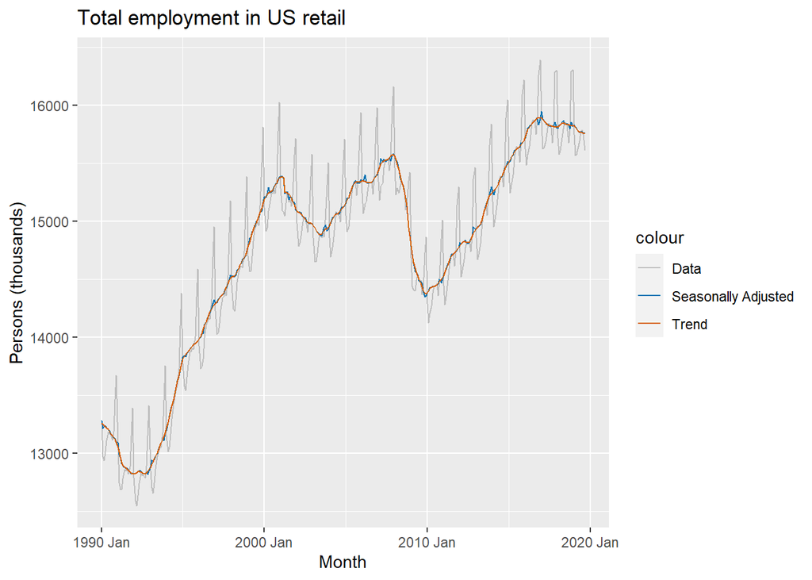

```r
x11_dcmp %>%
  ggplot(aes(x = Month)) +
  geom_line(aes(y = Employed, colour = "Data")) +
  geom_line(aes(y = season_adjust,
                colour = "Seasonally Adjusted")) +
  geom_line(aes(y = trend, colour = "Trend")) +
  labs(y = "Persons (thousands)",
       title = "Total employment in US retail") +
  scale_colour_manual(
    values = c("gray", "#0072B2", "#D55E00"),
    breaks = c("Data", "Seasonally Adjusted", "Trend")
  )
```

Seasonal sub-series plot of the seasonal component from the X-11 method applied to total US retail employment.

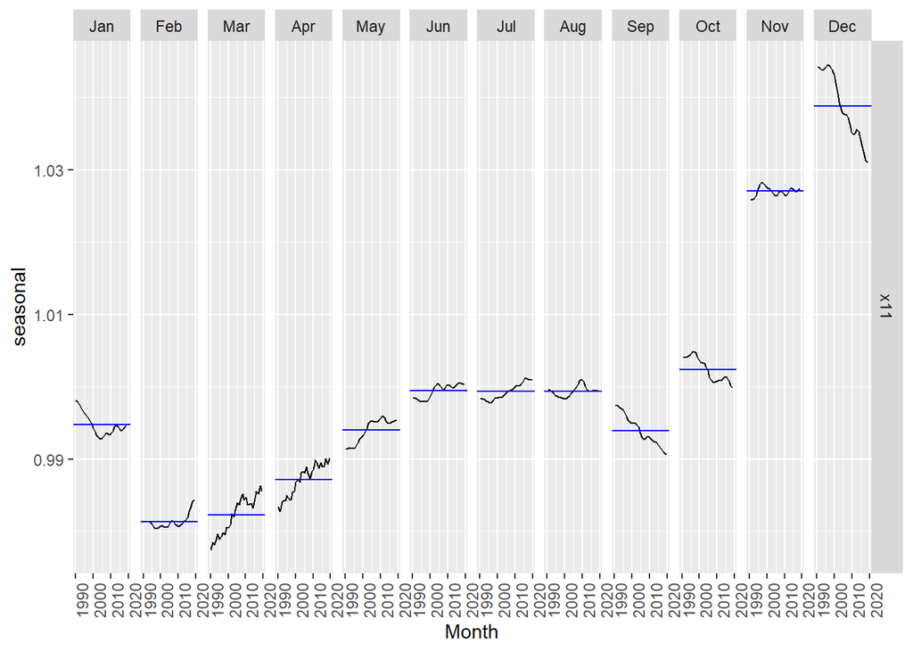

```r
x11_dcmp %>%
  gg_subseries(seasonal)
```

## SEATS method

Seasonal Extraction in ARIMA Time Series

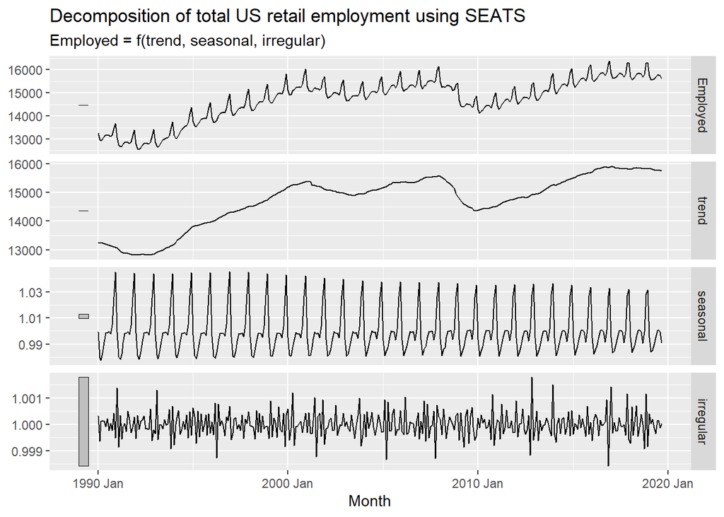

```r
seats_dcmp <- us_retail_employment %>%
  model(seats = X_13ARIMA_SEATS(Employed ~ seats())) %>%
  components()
autoplot(seats_dcmp) +
  labs(title =
    "Decomposition of total US retail employment using SEATS")
```

# 3.6 STL decomposition

## Questions

1. What is pivot_longer doing (line 47)
2. Formula of BoxCox
3. What is tsibble? A table? (line 90)
4. Does this transformations are based/same on the exponential regression?
5. Not sure about the remainder graph
6. Is this using a column or it’s a formula of seasonal behavior? line(137)
7. I am not sure about the difference between Multiplicative and additive decomposition in a practical point of view. I understand the difference in the formula.
8. I didn’t understand X11. (Classical method in Canada)
9. Different components in the last column: random, irregular and remainder.
10. The example in X_11 (line 205) has the same function as X_13ARIMA_SEATS (line 238)